# Narrative Approaches to Counting Roman Amphitheaters

Sebastian Heath sebastian.heath@nyu.edu

©2015 Sebastian Heath. Published under the terms of the [Creative Commons Attribution 4.0 Licence](http://creativecommons.org/licenses/by/4.0/).

## Introduction

Roman Amphitheaters form a class of massive, generally oval public structures that provided seating for thousands of spectators to watch public events and entertainments such as gladiatorial combat, animal fights and executions. This document considers amphitheaters from both quantitative and discursive perspectives in an effort to place them within an historical narrative. Numbers will be turned into visualizations that are in turn considered along side extended discussion and online digital media. The aim of what follows is to move from an initial examination of spatial distribution to issues of significance. In particular, how can we characterize the role of amphitheaters in an ancient state as large as the Roman Empire? Can they be considered in emblematic of Rome? A simple distribution map shows that the greater density of amphitheaters in the western Empire means that the answer cannot be a simple yes. While this opening observation is well known, the same map shows that amphitheaters are essentially only found within the territory of the empire. It is, however, useful at this time to note that the dot that appears north of Roman territory in Britain indicates the location of the amphitheater at Newstead, which town was under Roman military control at the time of the structure’s construction. This is a first indication that the construction of amphitheaters was a dynamic process. Indeed, well before the last amphitheater was constructed - perhaps the one in Sophia - many had already gone out of use. The most famous event ending the active period of an amphitheater was the eruption of Vesuvius in AD 79 and the resulting smothering and abandonment of the city of Pompeii. Since it is a goal of this document to provide an estimate of the total number of amphitheater seats at different times in the history of the Empire, it will be necessary to take account of first construction, renovation and abandonment or repurposing. In that regard, it is important to note that in its early stages, the data on which part of the following discuss is based does not yet directly record renovations in a a way that is readily useable in the visualizations it presents.

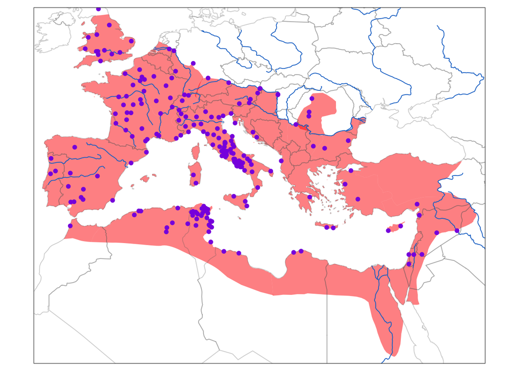

## Technical Note

This document is an experiment in progressive publication of data-rich scholarship. The primary dataset it relies on is the quantified data for Roman amphitheaters collected by the author. That is available in the Github repository http://github.com/sfsheath/roman-amphitheaters. It also makes use of other freely available datasets and maps, some of which have been collected by the author into the R package ‘cawd’, or *Collected Ancient World Data*, which is available at http://github.com/sfsheath/cawd . ‘cawd’ lists sources for the material it gathers, though that information will come to be repeated here.

It is also an experiment by way of being written using the Rmarkdown text-based format for authoring documents that seamlessly include maps and visualizations generated by R. For its part, R is an open-source application available at http://r-project.org and is often utilized within the context of http://rstudio.org, which provides a graphical front-end to R-based development and authoring. The code and text that are combined to form this document are currently available at http://github.com/sfsheath/R/narrative-counting.Rmd . This allows anyone to examine that generated the visualizations that appear here.

## The Place of Rome’s Flavian Amphitheater in a Quantified Study

http://commons.wikimedia.org/wiki/File:Colosseum_II.jpg

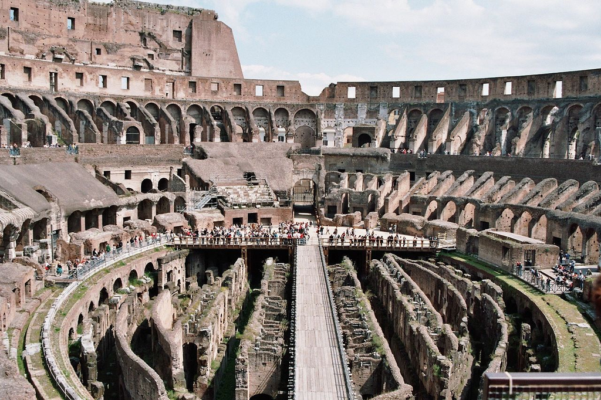

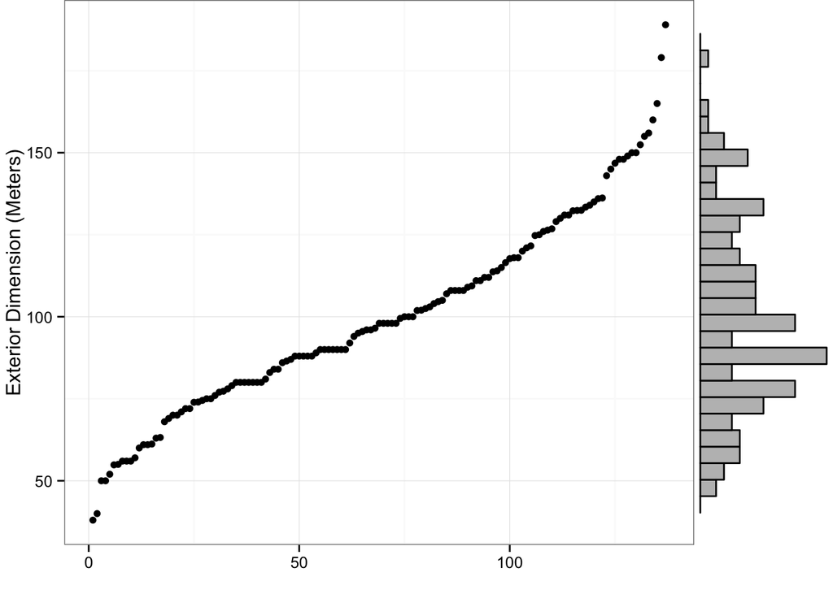

The marker at the top right indicates the size of the Flavian Amphitheater. It is no surprise that Rome was endowed with the largest amphitheater. This presentation of exterior lengths is, however, also a reminder that the presence of amphitheaters around the empire is typified by diversity of size, and likewise of experience, when the perspective of people attending events in amphitheaters is considered.